# PA1_template

GayathriMurali

April 19, 2015

This report is to understand the data from the personal activity monitoring device. We will walk through finding the mean and median of the steps taken per day and also plot data.

**Loading and Processing data**

Load data from the activity csv file

```r
data<-read.csv("activity.csv",stringsAsFactors = FALSE)
```

**What is mean total number of steps taken per day?** Calculating the total number of steps taken per day

```r
library(plyr)
total<-tapply(data$steps,data$date,FUN=sum,na.rm=FALSE)
```

Histogram representing the total number of steps taken each day

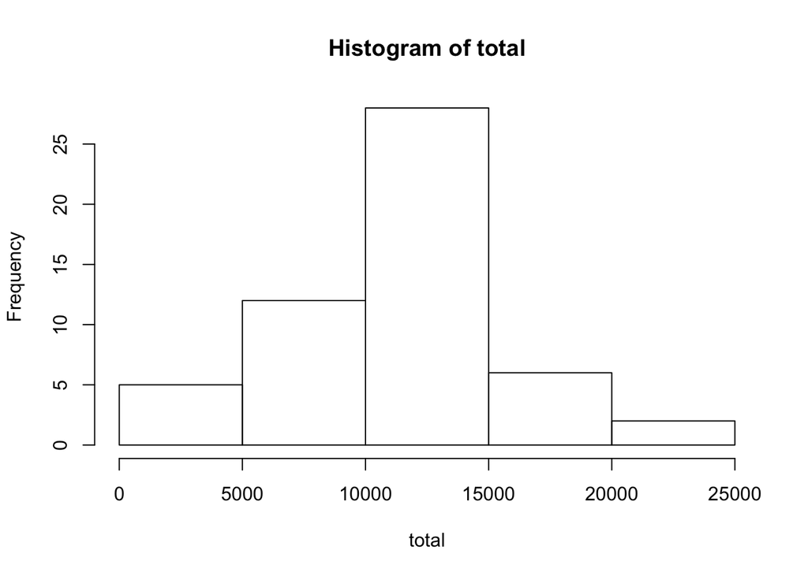

```r
hist(total)
```

Reporting the mean and median of the total number of steps taken per day

```r
mean(total,na.rm=TRUE)
```

```
## [1] 10766.19
```

```r
median(total,na.rm=TRUE)
```

```
## [1] 10765
```

**What is the average daily activity pattern?** Calculating the average number of steps per interval per day

```r
avgd<-tapply(data$steps,data$interval,FUN=mean,na.rm=TRUE)
avgd<-data.frame(cbind(rownames(avgd),avgd))
colnames(avgd)<-c("interval","interval_avg")
avgd$interval_avg <- as.numeric(as.character(avgd$interval_avg))
avgd$interval <- as.numeric(as.character(avgd$interval))
```

Plotting the time series type l plot of the 5-minute interval (x-axis) and the average number of steps taken, averaged across all days (y-axis)

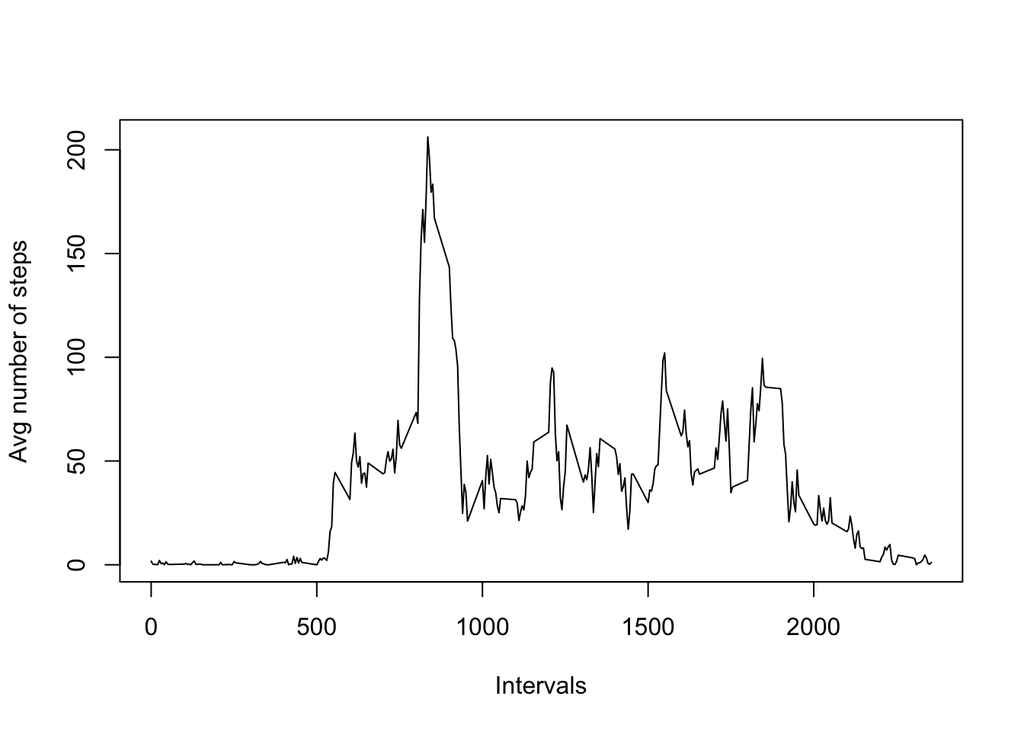

```r
plot(avgd$interval,avgd$interval_avg,type="l",xlab="Intervals",ylab="Avg number of steps")
```

Max nummber of steps on average across all the days in the dataset

```r
max(avgd$interval_avg)
```

```
## [1] 206.1698
```

**Imputing missing values** Calculating the total number of rows with missing values

```r
nrow(data[!complete.cases(data),])
```

```
## [1] 2304
```

```r
imputed<-merge(data,avgd)
imputed$new_steps <- imputed$steps
imputed$new_steps[is.na(imputed$new_steps)] <- imputed$interval_avg
```

Create a new dataset like the original dataset with NA values replaced

```r
newdata<-imputed[,c(1,3,5)]
newdata<-newdata[order(newdata$date,newdata$interval),]
```